# gRNA assignment for sceptre — full results

Every dataset, every method, every metric behind the recommendation memo

Published

July 3, 2026

This is the **full** results companion to `RECOMMENDATION.md`. The memo gives the decision and cross-dataset averages; here is everything underneath it — the per-dataset tables and every figure. The bottom line is unchanged: implement the **noise-conditioned per-entry test against a rank-1 denoised-ambient Poisson null** (`depth_fix`), the exact hypergeometric tail, Guo–Sarkar FDR.

# 1 The dataset landscape

Eleven real Perturb-seq datasets, chosen to span the axes that stress an assignment method: MOI (0.4→8.4), guide-capture depth (2→1858 UMIs/cell), guide count (17→27k), chemistry (direct-capture, CROP-seq, perturb-CITE, multiome), and biology (immortalized lines, primary cells, organoid, in vivo).

| dataset | guides | cells | med_lib | med_cellmax | med_topfrac | MOI_med | MOI_mean | n_NT_guides | n_targets | hasGE | nGenes | med_geUMI |
| --- | --- | --- | --- | --- | --- | --- | --- | --- | --- | --- | --- | --- |
| a549_crispri_perturbseq_GSE236304 | 253 | 25220 | 395 | 232 | 0.62 | 2 | 3.15 | 5 | 54 | TRUE | 36601 | 26167.5 |
| cd8_tcell_perturbcite_GSE279498 | 44 | 2426 | 2 | 1 | 1.00 | 0 | 0.42 | 2 | 22 | TRUE | 32285 | 2845.0 |
| dctap_k562_highmoi_GSE303901 | 110 | 10932 | 1858 | 486 | 0.26 | 8 | 8.42 | 98 | 4 | TRUE | 93 | 614.0 |
| dctap_k562_lowmoi_GSE303901 | 110 | 5397 | 353 | 299 | 0.86 | 1 | 1.65 | 98 | 4 | TRUE | 93 | 329.0 |
| endoc_t2d_perturbseq_GSE273677 | 225 | 41642 | 438 | 274 | 0.60 | 2 | 2.40 | 21 | 62 | TRUE | 36601 | 26038.0 |
| gastric_organoid_cropseq_GSE280506 | 96 | 42324 | 63 | 63 | 1.00 | 1 | 0.95 | NA | NA | FALSE | NA | NA |
| invivo_cortex_perturbseq_GSE249416 | 17 | 11688 | 259 | 232 | 0.97 | 1 | 1.21 | NA | NA | FALSE | NA | NA |
| ipsc_crispri_hipsci_figshare27989294 | 6824 | 322746 | 281 | 150 | 0.52 | 1 | 1.91 | NA | NA | FALSE | NA | NA |
| perturb_multiome_erythroid_GSE274113 | 63 | 14525 | 28 | 15 | 0.42 | 1 | 1.36 | NA | NA | TRUE | 36601 | 13322.0 |
| tcell_cd4_perturbseq_GSE314342 | 27272 | 137716 | 30 | 26 | 0.92 | 1 | 1.01 | 0 | 11891 | TRUE | 18130 | 7789.0 |
| replogle_rd7 | 2666 | 616184 | 1174 | 954 | 0.81 | NA | NA | 113 | 2386 | FALSE | NA | NA |

`med_topfrac` = median fraction of a cell’s guide UMIs in its top guide (→1 = low MOI). `MOI_med/mean` = guides per cell above an adaptive threshold. `hasGE` / `nGenes` = gene-expression availability (needed for downstream DE). Note **dctap has only 93 genes** (a targeted panel — unusable for DE calibration covariates) and **cd8 has median guide library 2** (degenerate capture). These two are used for the ambient/upstream analyses but excluded from downstream-DE calibration (§4).

# 2 Ambient-null validation (all 11 datasets)

Both load-bearing modeling choices — the **Poisson null** and the **denoised depth** — were checked on every dataset by fitting the fishash-style rank-1 denoised ambient (carrier-masked IPF; a from- scratch reimplementation in `scripts/ambient_validation.R`) and measuring the aggregate soup dispersion var/mean vs the fitted rate $\mu = a_g d_c$ (zeros handled analytically).

| dataset | n_guides | n_cells | frac_carrier | disp_mod | disp_hi | depth_ratio_lib_over_denoised | med_denoised_depth |
| --- | --- | --- | --- | --- | --- | --- | --- |
| a549_crispri_perturbseq_GSE236304 | 253 | 25220 | 0.643 | 1.242 | 2.312 | 188.0 | 3.0 |
| cd8_tcell_perturbcite_GSE279498 | 44 | 2426 | 0.373 | NA | 2.185 | 1.0 | 2.0 |
| dctap_k562_highmoi_GSE303901 | 110 | 10932 | 0.180 | 1.305 | 3.354 | 15.8 | 117.7 |
| dctap_k562_lowmoi_GSE303901 | 110 | 5397 | 0.040 | 1.048 | 1.352 | 10.3 | 40.0 |
| endoc_t2d_perturbseq_GSE273677 | 225 | 41642 | 0.266 | 1.034 | 1.150 | 74.5 | 6.1 |
| gastric_organoid_cropseq_GSE280506 | 96 | 42324 | 0.944 | 1.469 | 3.154 | 126.0 | 1.0 |
| invivo_cortex_perturbseq_GSE249416 | 17 | 11688 | 0.249 | 1.510 | 2.161 | 45.1 | 6.4 |
| ipsc_crispri_hipsci_figshare27989294 | 6824 | 300000 | 0.040 | 1.197 | 2.090 | 5.1 | 61.0 |
| perturb_multiome_erythroid_GSE274113 | 63 | 14525 | 0.102 | 1.153 | 1.789 | 2.5 | 10.8 |
| tcell_cd4_perturbseq_GSE314342 | 27272 | 137716 | 0.388 | 1.067 | NA | 20.0 | 2.0 |
| replogle_rd7 | 2666 | 300000 | 0.065 | 1.044 | 1.117 | 71.8 | 18.0 |

**Aggregate dispersion vs rate, all datasets overlaid** — flat at 1.0 at low rates (where most ambient mass lives), rising mildly in the tail:

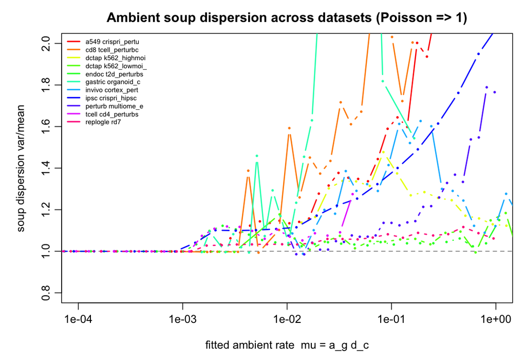

Ambient soup dispersion across datasets

**Per-dataset facets** (same data, one panel each — note the y-axis: all sit near the Poisson line 1.0 at low $\mu$, drift up only in the sparse high-rate tail):

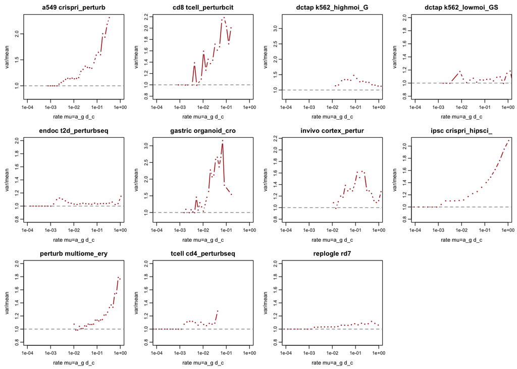

Per-dataset ambient dispersion

# 3 Upstream accuracy — vs ground truth & simulators

## 3.1 Real barnyard ground truth (Liu 2025)

Wrong-species guides are provably ambient. Metric = fishash Table-2 per-cell accuracy (≥1 correct- species and 0 wrong-species guides), by chemistry × timepoint:

| method | mix0hr_Cropseq | mix72hr_Cropseq | mix0hr_DirectCapture | mix72hr_DirectCapture | mean |
| --- | --- | --- | --- | --- | --- |
| ours (ambient) | 0.9539 | 0.9533 | 0.9335 | 0.9642 | 0.9512 |
| fishash (exact) | 0.9563 | 0.9533 | 0.9100 | 0.9491 | 0.9422 |
| valley | 0.9427 | 0.9414 | 0.8520 | 0.9223 | 0.9146 |
| otsu | 0.9430 | 0.9448 | 0.8608 | 0.9069 | 0.9139 |
| geomux (exact) | 0.9578 | 0.9555 | 0.7471 | 0.5252 | 0.7964 |

All noise-conditioned methods land ~0.94; geomux collapses on direct capture (adaptive threshold blown up by the heavy real-ambient tail). Barnyard is low-MOI, so `depth_fix`’s high-MOI advantage cannot appear — this is a **no-regression** check.

## 3.2 Simulation panel (per-guide accuracy)

Full method panel, per-guide precision/recall/Jaccard/FDR vs the integrated-AND-observed truth (`results/sim_framework/method_overall.csv`):

| method | jaccard | precision | recall | FDR |
| --- | --- | --- | --- | --- |
| depth_fix | 0.854 | 0.962 | 0.887 | 0.041 |
| thresh3 | 0.835 | 0.955 | 0.875 | 0.070 |
| crispat | 0.822 | 0.974 | 0.843 | 0.040 |
| fishash | 0.806 | 0.974 | 0.828 | 0.027 |
| ambient | 0.739 | 0.871 | 0.859 | 0.142 |
| valley | 0.731 | 0.983 | 0.743 | 0.018 |
| sceptre | 0.722 | 0.967 | 0.750 | 0.055 |
| otsu | 0.700 | 0.917 | 0.778 | 0.165 |
| thresh10 | 0.668 | 0.982 | 0.680 | 0.021 |
| thresh20 | 0.550 | 0.989 | 0.555 | 0.011 |
| geomux | 0.381 | 0.980 | 0.392 | 0.032 |

## 3.3 depth_fix vs fishash by MOI — the core of the cell-margin fix

| moi_level | method | jaccard | recall |
| --- | --- | --- | --- |
| low | fishash | 0.813 | 0.849 |
| low | depth_fix | 0.834 | 0.881 |
| high | fishash | 0.806 | 0.817 |
| high | depth_fix | 0.864 | 0.877 |
| vhigh | fishash | 0.756 | 0.759 |
| vhigh | depth_fix | 0.849 | 0.853 |

`depth_fix` beats `fishash` at every MOI and the gap widens as MOI rises (the recall `fishash` loses to co-occurring guides is exactly what the depth decontamination recovers).

## 3.4 Per-regime simulation table (Model B mechanistic regimes)

| regime | separation | mu_pert.x | moi.x | target_pct3 | sim_pct3 | best | depth_fix | thresh3 |
| --- | --- | --- | --- | --- | --- | --- | --- | --- |
| replogle | 6.81 | 814 | 2 | 0.9 | 2.4 | depth_fix | 0.99 | 0.95 |
| dctap_k562_lowmoi_GSE303901 | 6.05 | 518 | 1 | 12.1 | 9.5 | crispat | 0.74 | 0.68 |
| barnyard_72hr_DirectCapture | 5.87 | 353 | 3 | 3.7 | 2.9 | depth_fix | 0.96 | 0.95 |
| endoc_t2d_perturbseq_GSE273677 | 5.39 | 238 | 2 | 2.2 | 3.0 | crispat | 0.94 | 0.91 |
| invivo_cortex_perturbseq_GSE249416 | 5.26 | 390 | 1 | 22.0 | 20.2 | valley | 0.60 | 0.41 |
| dctap_k562_highmoi_GSE303901 | 5.12 | 195 | 9 | 34.1 | 29.9 | valley | 0.82 | 0.73 |
| a549_crispri_perturbseq_GSE236304 | 4.62 | 83 | 3 | 10.3 | 9.7 | crispat | 0.88 | 0.73 |
| gastric_organoid_cropseq_GSE280506 | 4.45 | 84 | 1 | 33.8 | 26.7 | valley | 0.60 | 0.56 |
| tcell_cd4_perturbseq_GSE314342 | 4.39 | 80 | 3 | 0.0 | 1.2 | thresh3 | 0.99 | 1.00 |
| schraivogel | 4.16 | 66 | 1 | 2.9 | 1.8 | depth_fix | 0.98 | 0.92 |
| ipsc_crispri_hipsci_figshare27989294 | 3.65 | 52 | 8 | 3.2 | 3.8 | depth_fix | 0.91 | 0.88 |
| perturb_multiome_erythroid_GSE274113 | 3.30 | 27 | 1 | 4.3 | 4.1 | depth_fix | 0.98 | 0.96 |
| barnyard_0hr_DirectCapture | 2.89 | 18 | 4 | 13.6 | 14.2 | depth_fix | 0.83 | 0.76 |
| barnyard_0hr_Cropseq | 2.56 | 12 | 5 | 5.7 | 6.1 | depth_fix | 0.89 | 0.86 |
| barnyard_72hr_Cropseq | 2.48 | 11 | 5 | 3.6 | 5.0 | depth_fix | 0.90 | 0.86 |
| gasperini | 2.40 | 10 | 25 | 14.3 | 14.0 | thresh3 | 0.78 | 0.80 |
| cd8_tcell_perturbcite_GSE279498 | 1.87 | 8 | 1 | 15.9 | 14.4 | fishash | 0.65 | 0.59 |

# 4 Downstream DE — the decisive test, in full

Every dataset with genome-wide gene expression and non-targeting guides was pushed through sceptre’s **native** `run_calibration_check` (negative-control type-I error) and `run_power_check` (on-target power), 2000 negative-control pairs each. Scripts: `de_native.R`, `de_driver.R`, `de_aggregate.R`.

## 4.1 The full per-(dataset, method) table

**Nothing averaged** — every run. `cal_n` = # negative-control pairs; `t1e05/01/001` = realized type-I error at those nominal levels; `ks` = KS distance from uniform; `mlog10_mean` = mean −log₁₀ p (uniform ⇒ 0.434); `pow_n` = # on-target pairs; `pow_frac05` = fraction on-target p<0.05; `med_abs_lfc` = median |log₂ fold-change| on targets.

| dataset | method | moi | n_calls | cal_n | t1e05 | t1e01 | ks | mlog10_mean | pow_n | pow_med_p | pow_frac05 | med_abs_lfc | trustworthy |
| --- | --- | --- | --- | --- | --- | --- | --- | --- | --- | --- | --- | --- | --- |
| a549 | ambient | high | 67171 | 2000 | 0.060 | 0.017 | 0.144 | 0.410 | 53 | 0.636 | 0.132 | 0.025 | TRUE |
| a549 | cleanser | high | 57937 | 2000 | 0.050 | 0.013 | 0.138 | 0.386 | 53 | 0.464 | 0.094 | 0.039 | TRUE |
| a549 | crispat | high | 65786 | 2000 | 0.052 | 0.014 | 0.144 | 0.402 | 53 | 0.516 | 0.094 | 0.032 | TRUE |
| a549 | depth_fix | high | 69734 | 2000 | 0.070 | 0.024 | 0.134 | 0.435 | 53 | 0.468 | 0.094 | 0.032 | TRUE |
| a549 | fishash | high | 56931 | 2000 | 0.054 | 0.013 | 0.158 | 0.389 | 53 | 0.516 | 0.132 | 0.035 | TRUE |
| a549 | sceptre | high | 60963 | 2000 | 0.055 | 0.018 | 0.152 | 0.406 | 53 | 0.484 | 0.151 | 0.030 | TRUE |
| a549 | thresh3 | high | 67997 | 2000 | 0.066 | 0.022 | 0.132 | 0.438 | 53 | 0.484 | 0.094 | 0.033 | TRUE |
| cd8_tcell | ambient | low | 1488 | 0 | NA | NA | NA | NA | 21 | 0.580 | 0.095 | 0.018 | FALSE |
| cd8_tcell | depth_fix | low | 1119 | 0 | NA | NA | NA | NA | 21 | 0.624 | 0.143 | 0.002 | FALSE |
| cd8_tcell | depth_fix_nb | low | 44 | 0 | NA | NA | NA | NA | 0 | NA | NA | NA | FALSE |
| cd8_tcell | fishash | low | 1061 | 0 | NA | NA | NA | NA | 21 | 0.604 | 0.190 | 0.003 | FALSE |
| cd8_tcell | sceptre | low | 872 | 0 | NA | NA | NA | NA | 0 | NA | NA | NA | FALSE |
| cd8_tcell | thresh3 | low | 1040 | 0 | NA | NA | NA | NA | 0 | NA | NA | NA | FALSE |
| dctap_highmoi | ambient | high | 103024 | 2000 | 0.166 | 0.080 | 0.156 | 0.739 | 3 | 0.000 | 1.000 | 0.312 | FALSE |
| dctap_highmoi | depth_fix | high | 116407 | 2000 | 0.233 | 0.128 | 0.216 | 0.914 | 3 | 0.000 | 1.000 | 0.277 | FALSE |
| dctap_highmoi | depth_fix_nb | high | 94148 | 2000 | 0.177 | 0.088 | 0.168 | 0.786 | 3 | 0.000 | 1.000 | 0.385 | FALSE |
| dctap_highmoi | fishash | high | 94739 | 2000 | 0.187 | 0.085 | 0.171 | 0.769 | 3 | 0.000 | 1.000 | 0.380 | FALSE |
| dctap_highmoi | sceptre | high | 80703 | 2000 | 0.096 | 0.042 | 0.080 | 0.562 | 3 | 0.000 | 1.000 | 0.427 | FALSE |
| dctap_highmoi | thresh3 | high | 290265 | 2000 | 0.213 | 0.119 | 0.220 | 0.889 | 3 | 0.000 | 1.000 | 0.033 | FALSE |
| dctap_lowmoi | ambient | low | 6127 | 2000 | 0.120 | 0.046 | 0.114 | 0.613 | 3 | 0.000 | 1.000 | 0.538 | FALSE |
| dctap_lowmoi | depth_fix | low | 6375 | 2000 | 0.113 | 0.044 | 0.104 | 0.601 | 3 | 0.000 | 1.000 | 0.523 | FALSE |
| dctap_lowmoi | depth_fix_nb | low | 6374 | 2000 | 0.114 | 0.045 | 0.109 | 0.602 | 3 | 0.000 | 1.000 | 0.523 | FALSE |
| dctap_lowmoi | fishash | low | 5944 | 2000 | 0.120 | 0.045 | 0.111 | 0.611 | 3 | 0.000 | 1.000 | 0.536 | FALSE |
| dctap_lowmoi | sceptre | low | 7846 | 2000 | 0.094 | 0.025 | 0.077 | 0.537 | 3 | 0.000 | 1.000 | 0.521 | FALSE |
| dctap_lowmoi | thresh3 | low | 22388 | 2000 | 0.059 | 0.016 | 0.037 | 0.464 | 3 | 0.001 | 1.000 | 0.507 | FALSE |
| endoc | ambient | high | 40817 | 2000 | 0.059 | 0.015 | 0.112 | 0.409 | 61 | 0.000 | 0.820 | 1.582 | TRUE |
| endoc | cleanser | high | 39493 | 2000 | 0.053 | 0.014 | 0.114 | 0.395 | 61 | 0.000 | 0.803 | 1.632 | TRUE |
| endoc | crispat | high | 39719 | 2000 | 0.049 | 0.010 | 0.107 | 0.403 | 61 | 0.000 | 0.820 | 1.583 | TRUE |
| endoc | depth_fix | high | 40803 | 2000 | 0.056 | 0.013 | 0.114 | 0.406 | 61 | 0.000 | 0.820 | 1.534 | TRUE |
| endoc | depth_fix_nb | high | 58 | 2000 | 0.028 | 0.006 | 0.187 | 0.299 | 61 | 0.000 | 0.934 | 0.241 | TRUE |
| endoc | fishash | high | 39137 | 2000 | 0.050 | 0.013 | 0.114 | 0.392 | 61 | 0.000 | 0.820 | 1.625 | TRUE |
| endoc | sceptre | high | 39179 | 2000 | 0.052 | 0.013 | 0.111 | 0.392 | 61 | 0.000 | 0.820 | 1.652 | TRUE |
| endoc | thresh3 | high | 40915 | 2000 | 0.052 | 0.014 | 0.102 | 0.406 | 61 | 0.000 | 0.803 | 1.574 | TRUE |
| gasperini | ambient | high | 1046602 | 2000 | 0.046 | 0.009 | 0.016 | 0.425 | 377 | 0.000 | 0.939 | 0.883 | TRUE |
| gasperini | depth_fix | high | 892133 | 2000 | 0.048 | 0.007 | 0.018 | 0.435 | 377 | 0.000 | 0.950 | 1.025 | TRUE |
| gasperini | fishash | high | 839088 | 2000 | 0.048 | 0.007 | 0.022 | 0.433 | 377 | 0.000 | 0.947 | 1.052 | TRUE |
| gasperini | sceptre | high | 861130 | 2000 | 0.048 | 0.011 | 0.019 | 0.433 | 377 | 0.000 | 0.944 | 1.025 | TRUE |
| gasperini | thresh3 | high | 860360 | 2000 | 0.048 | 0.009 | 0.020 | 0.433 | 377 | 0.000 | 0.944 | 1.029 | TRUE |
| replogle | ambient | low | 55760 | 2000 | 0.036 | 0.006 | 0.029 | 0.421 | 2383 | 0.116 | 0.415 | 1.742 | TRUE |
| replogle | cleanser | low | 19518 | 2000 | 0.051 | 0.010 | 0.038 | 0.447 | 2383 | 0.128 | 0.410 | 1.402 | TRUE |
| replogle | depth_fix | low | 38246 | 2000 | 0.051 | 0.014 | 0.056 | 0.461 | 2383 | 0.168 | 0.366 | 1.313 | TRUE |
| replogle | fishash | low | 34194 | 2000 | 0.058 | 0.014 | 0.043 | 0.465 | 2383 | 0.152 | 0.372 | 1.450 | TRUE |
| replogle | sceptre | low | 38276 | 2000 | 0.043 | 0.014 | 0.036 | 0.435 | 2383 | 0.148 | 0.379 | 1.278 | TRUE |
| replogle | thresh3 | low | 37068 | 2000 | 0.043 | 0.007 | 0.035 | 0.425 | 2383 | 0.140 | 0.396 | 1.481 | TRUE |

## 4.3 Per-dataset calibration QQ plots (genome-wide datasets)

The actual null p-value distributions — not just the t1e summary. On the diagonal = calibrated. All methods track the diagonal through the bulk; mild shared tail inflation on a549/replogle; near-perfect on gasperini:

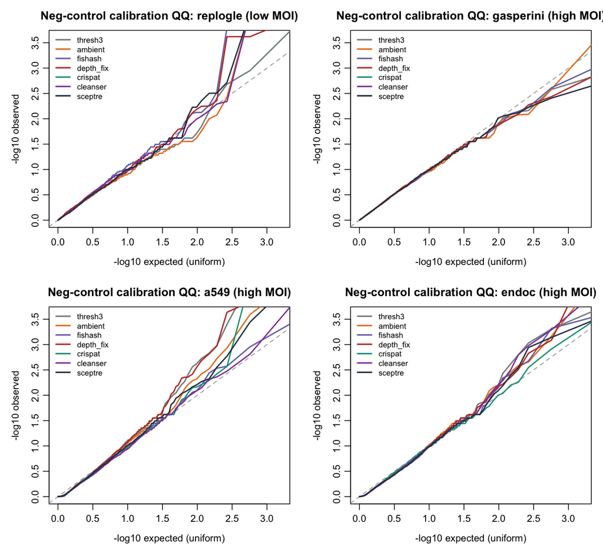

Calibration QQ by dataset

## 4.4 Per-dataset type-I error (all 7 DE datasets)

Bars = negative-control t1e@0.05 per method; dashed line = nominal 0.05. The genome-wide datasets (replogle, gasperini, a549, endoc) hug 0.05; the dctap panels are inflated for everyone (the 93-gene artifact); cd8 is degenerate:

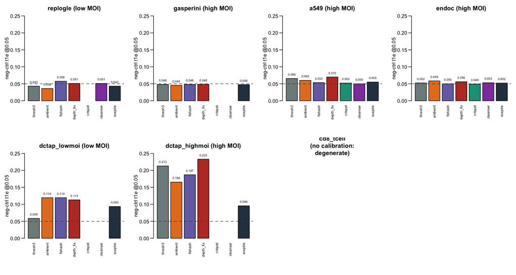

Per-dataset DE calibration

## 4.5 Assignment counts per method per dataset

How many (guide, cell) pairs each method calls — the over-/under-calling that drives the precision/recall and downstream power trade-offs (`ambient` over-calls; the mixture under-calls):

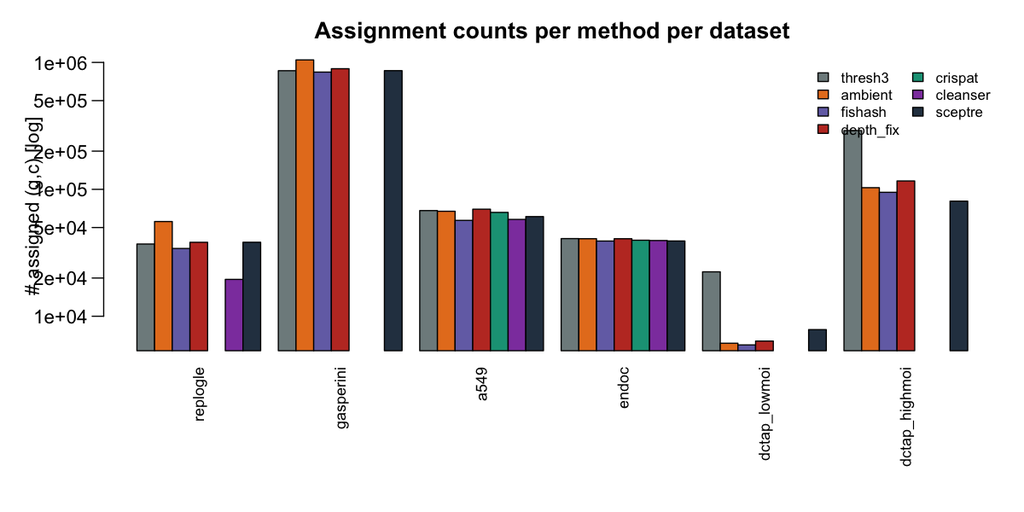

Assignment counts

## 4.6 Per-guide-model methods: crispat and CLEANSER

The two published per-guide model-fitting methods were added to the downstream DE comparison (installed fresh this cycle: crispat’s Poisson-Gaussian mixture from `.venv_crispat`; CLEANSER’s Stan MCMC mixture from the Gersbach-lab GitHub + CmdStan 2.39). They were run through the identical sceptre DE harness on the genome-wide datasets where per-guide fitting is tractable: **CLEANSER on a549, endoc, replogle; crispat on a549, endoc** (crispat’s per-guide SVI on replogle’s 2,666 guides is very slow and was not included here). **Gasperini was not run for either**: at 13k guides, crispat’s per-guide SVI (~1 guide/s → hours) and CLEANSER’s per-guide MCMC are computationally prohibitive — itself a relevant finding (the vectorized rank-1 contingency test runs the same data in ~1 min).

|  | dataset | method | n_calls | t1e05 | t1e01 | ks | pow_frac05 | med_abs_lfc |
| --- | --- | --- | --- | --- | --- | --- | --- | --- |
| 2 | a549 | cleanser | 57937 | 0.050 | 0.013 | 0.138 | 0.094 | 0.039 |
| 3 | a549 | crispat | 65786 | 0.052 | 0.014 | 0.144 | 0.094 | 0.032 |
| 4 | a549 | depth_fix | 69734 | 0.070 | 0.024 | 0.134 | 0.094 | 0.032 |
| 5 | a549 | fishash | 56931 | 0.054 | 0.013 | 0.158 | 0.132 | 0.035 |
| 27 | endoc | cleanser | 39493 | 0.053 | 0.014 | 0.114 | 0.803 | 1.632 |
| 28 | endoc | crispat | 39719 | 0.049 | 0.010 | 0.107 | 0.820 | 1.583 |
| 29 | endoc | depth_fix | 40803 | 0.056 | 0.013 | 0.114 | 0.820 | 1.534 |
| 31 | endoc | fishash | 39137 | 0.050 | 0.013 | 0.114 | 0.820 | 1.625 |
| 40 | replogle | cleanser | 19518 | 0.051 | 0.010 | 0.038 | 0.410 | 1.402 |
| 41 | replogle | depth_fix | 38246 | 0.051 | 0.014 | 0.056 | 0.366 | 1.313 |
| 42 | replogle | fishash | 34194 | 0.058 | 0.014 | 0.043 | 0.372 | 1.450 |

## 4.7 Trustworthy-only averages (the memo’s table)

|  | method | t1e05 | t1e01 | ks | pow_med_p | pow_frac05 | med_abs_lfc |
| --- | --- | --- | --- | --- | --- | --- | --- |
| 1 | ambient | 0.050 | 0.012 | 0.075 | 0.188 | 0.576 | 1.058 |
| 2 | cleanser | 0.051 | 0.012 | 0.097 | 0.197 | 0.436 | 1.024 |
| 3 | crispat | 0.051 | 0.012 | 0.126 | 0.258 | 0.457 | 0.808 |
| 7 | sceptre | 0.049 | 0.014 | 0.079 | 0.158 | 0.573 | 0.996 |
| 6 | fishash | 0.052 | 0.012 | 0.084 | 0.167 | 0.568 | 1.040 |
| 8 | thresh3 | 0.052 | 0.013 | 0.072 | 0.156 | 0.560 | 1.029 |
| 4 | depth_fix | 0.056 | 0.014 | 0.080 | 0.159 | 0.557 | 0.976 |
| 5 | depth_fix_nb | 0.028 | 0.006 | 0.187 | 0.000 | 0.934 | 0.241 |

# 5 The negative result — the NB null collapses

|  | dataset | depth_fix | depth_fix_nb |
| --- | --- | --- | --- |
| 4 | a549 | 69734 | NA |
| 9 | cd8_tcell | 1119 | 44 |
| 15 | dctap_highmoi | 116407 | 94148 |
| 21 | dctap_lowmoi | 6375 | 6374 |
| 29 | endoc | 40803 | 58 |
| 35 | gasperini | 892133 | NA |
| 41 | replogle | 38246 | NA |

# 6 Synthesis

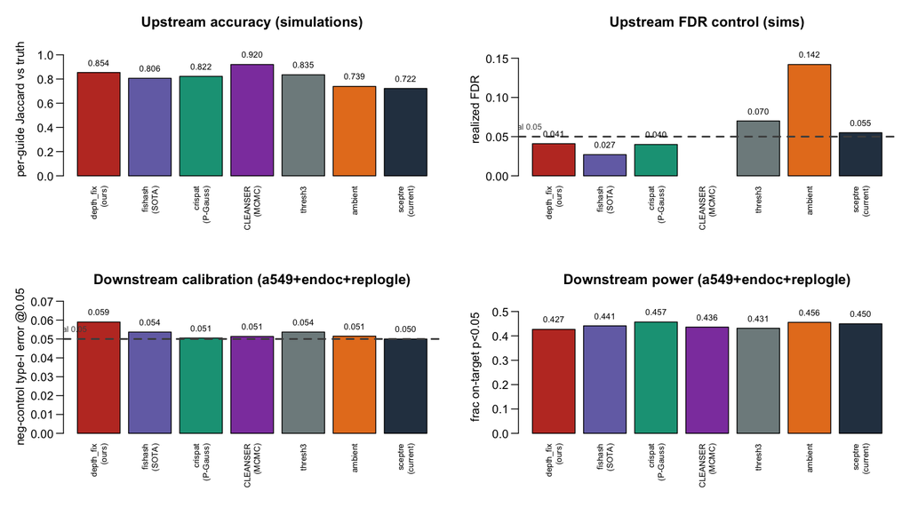

Method scorecard